# Exploratory Analyses 2

Devin Gamble

4/22/2020

### Objective: Explore Models of DOY

See ‘EDA1.Rmd’ for exploration of variables from the georeferrenced herbarium records and ‘EDA_climate.Rmd’ for ClimateNA variables (mostly distributions).

**In This Document**  
1. DOY ~ Non-climatic variables [line 100]  
2. Correlations among variables [line 125] (Model Diagnostic code [line 190])  
3. How has climate change over time [line 240]  
4. What is the effect of Error distance on models? [?line 400?]  
5. Exploratory DOY~Climate models [???700?]

#### Notes on Data sets and Organization:

Through separate rounds of cleaning and duplicate removal, georeferencing, obtaining climate data, and (soon) scoring, there are several different csv files with *Nemophila* specimen data present in this project repository. For clarity, they are listed out her detailing what they contain and how recently they were made.

**Specimen Records**:  
These csv files can be found in the ‘data_cleaning’ folder. They include

CCH1 Data:  
- `Nemo_CCH1_02182020.csv` - CCH1 data set standardized by Ivana  
- `nemo_cch1_cleaned.csv` - cleaned (by DG) CCH1 data set - Georeferenced CCH1 splits (folder) - split by herbarium and georeferenced; combined with CCH2 data

CCH2 Data:  
- `occurrences.csv` - the original specimen data downloaded from CCH2  
- `nemo_cch2_Dec2019.csv` - cleaned up from the occurrences data  
- `nemo_cch2_cleaned_V2.csv` - further cleaning, removing duplicates. This was then split up into subsets by herbarium for georeferencing & scoring.  
- Splits for PI folder has most recent cleaned CCH2 splits ("_pi.csv" files are more up to date! Dupes & odd things removed, data re-split by CCH2 herbaria *after* running `combine_cch1_cch2_V2.R` script)

Combined CCH1 & CCH2:  
* See “combine_cch1_cch2_V2.R” for more details.  
- `cch1&2_combined.csv` - attempt at combination, NOT cleaned  
- `nemo_all_1.csv` - first updated combination of CCH1 and CCH2 records  
- `nemo_all_2.csv` - second combination of CCH1 and CCH2 records, added elevation (m) from ‘elevatr’ package. (Used to make latest PI splits). **Most up-to-date combined specimen data!!**

**Climate Data**:  
See “get_cna_all.Rmd” for more details. Uses `nemo_all_2.csv` as input to create ClimateNA compatible csv `all_CNA_s.csv`.  
- First-attempt CCH1 and 2 climate data can be found in their respective folders under “ClimateNA”  
- ClimateNA downloads are in the “cna_rawfiles” folder, in the “all_CNA” folder under  
- These were cleaned and combined to get `norms_raw_51_and_81.csv`, `YoC_Y_and_L1.csv`, `100y_avg.csv`  
- Anomalies calculated in ‘get_cna_anoms.Rmd’, creates `climNA_anoms.csv`  
- All the above data sets combined into `climNA_nemo_all.csv` saved in “all_cna” folder **Most up-to-date Climate-only data!!**

**Combined data sets**:  
In this Rmd, `nemo_all_2.csv`, with added error distance, and `climNA_nemo_all.csv`, with PPT vars. log-transformed, are combined and saved to `nemo_full_1901_2019.csv`, filtering for years only from 1901-2019. **Most up-to-date combined file!!**

```
## [1] 1665
```

```
## [1] 1677
```

**Add back in Collector information for CCH1 and CCH2 specimen records!**

Create subset of data where each observation has an error distance:

```r
#Filter specimens to those collected after 1900
nemo_df2 <- nemo_df1 %>%
  filter(year >= 1901) #1677 obs

nemo_all_errors <- nemo_df2 %>%
  filter(!is.na(error_dist_m))
#1239 out of 1764 obs with error distance
#1166 after rm records before 1901

#0-5 km resolution
nemo_e0_5 <- nemo_all_errors %>%
  filter(error_bin == "<2 km" | error_bin == "2-5 km") #1081 entries

#0-4 km
nemo_e0_4 <-  nemo_all_errors %>%
  filter(error_dist_m >= 0 & error_dist_m <= 4000) #1010 obs #Do Not include error_bin in models

#0-2 km
nemo_e2 <- nemo_all_errors %>%
  filter(error_bin == "<2 km") #761 obs
```

A combined data set (`nemo_df2`) is saved within ‘Climate_1.Rmd’ and titled ‘nemo_full_1901_2019.csv’

## How does DoY depend on non-climatic variables?

```r
lm1 <- lm(DOY ~ elev_m + year + long, data = nemo_df1) #all years
lm1.1 <- lm(DOY ~ elev_m + year + long, data = nemo_df2) #>1900
summary(lm1.1)
```

```
##
## Call:
## lm(formula = DOY ~ elev_m + year + long, data = nemo_df2)
##
## Residuals:
##     Min      1Q  Median      3Q     Max
## -82.910 -15.582  -1.128  15.397 154.005
##
## Coefficients:
##              Estimate Std. Error t value Pr(>|t|)
## (Intercept) 46.300290  56.545646   0.819    0.413
## elev_m       0.034443   0.001503  22.922  < 2e-16 ***
## year        -0.081101   0.019615  -4.135 3.73e-05 ***
## long        -1.625230   0.304711  -5.334 1.09e-07 ***
## ---
## Signif. codes:  0 '***' 0.001 '**' 0.01 '*' 0.05 '.' 0.1 ' ' 1
##
## Residual standard error: 25.35 on 1673 degrees of freedom
## Multiple R-squared:  0.254,  Adjusted R-squared:  0.2526
## F-statistic: 189.9 on 3 and 1673 DF,  p-value: < 2.2e-16
```

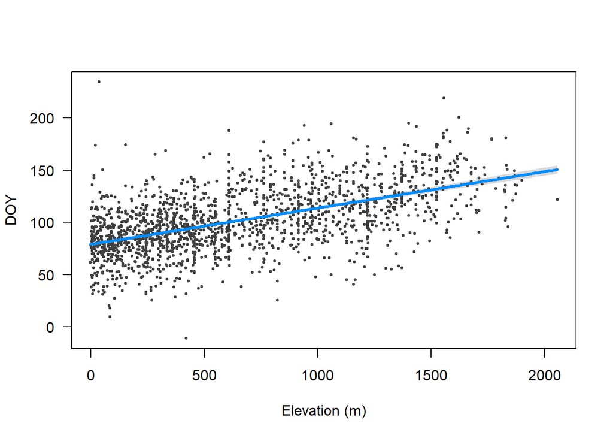

```r
#summary(lm1.1)

visreg(lm1, xvar = "elev_m", xlab = "Elevation (m)", points = list(col = "#404040"))
```

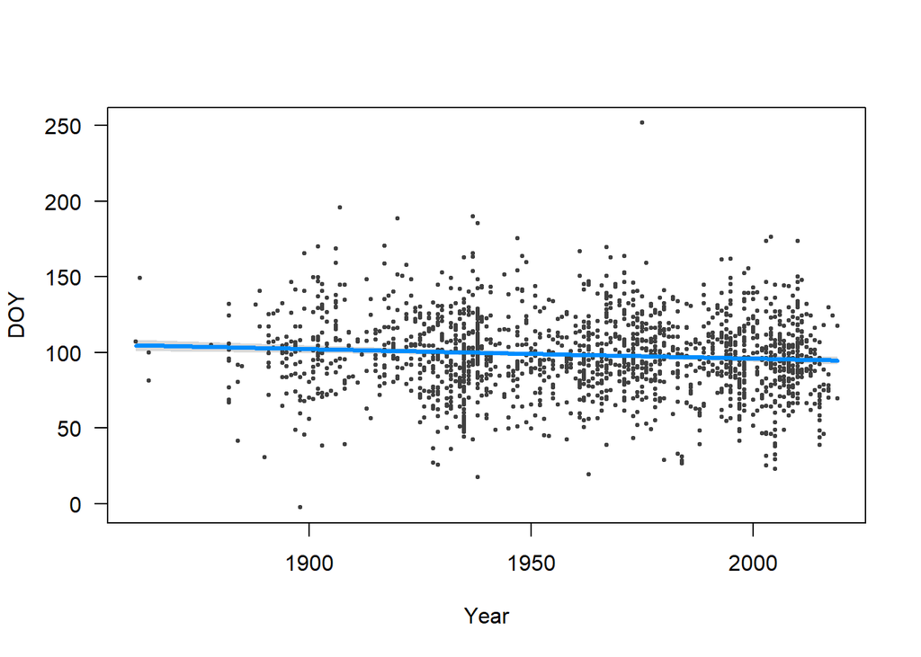

```r
visreg(lm1, "year", xlab = "Year", points = list(col = "#404040"))
```

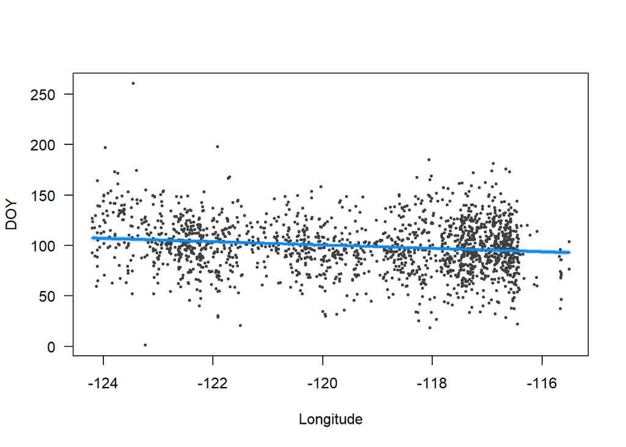

```r
visreg(lm1, "long", xlab = "Longitude", points = list(col = "#404040"))
```

```r
lm1.2 <- lm(DOY ~ elev_m + year + long + long*elev_m, data = nemo_df2)
summary(lm1.2)
```

```
##
## Call:
## lm(formula = DOY ~ elev_m + year + long + long * elev_m, data = nemo_df2)
##
## Residuals:
##     Min      1Q  Median      3Q     Max
## -81.372 -15.276  -1.167  15.012 151.617
##
## Coefficients:
##               Estimate Std. Error t value Pr(>|t|)
## (Intercept) -3.388e+01  6.991e+01  -0.485   0.6280
## elev_m       1.781e-01  7.379e-02   2.413   0.0159 *
## year        -8.112e-02  1.960e-02  -4.139 3.66e-05 ***
## long        -2.296e+00  4.598e-01  -4.994 6.53e-07 ***
## elev_m:long  1.211e-03  6.217e-04   1.947   0.0517 .
## ---
## Signif. codes:  0 '***' 0.001 '**' 0.01 '*' 0.05 '.' 0.1 ' ' 1
##
## Residual standard error: 25.33 on 1672 degrees of freedom
## Multiple R-squared:  0.2557, Adjusted R-squared:  0.2539
## F-statistic: 143.6 on 4 and 1672 DF,  p-value: < 2.2e-16
```

```r
#No interactions with year
#interact_plot(lm1.2, pred = "long", modx = "elev_m")

#summ(lm1.1, vif = TRUE) #VIF for long, elev, MAP, MAT is high
```

## Variable Correlations:

Which geographical and climate variables are correlated with one another?  
(And how could these make future analyses difficult?)

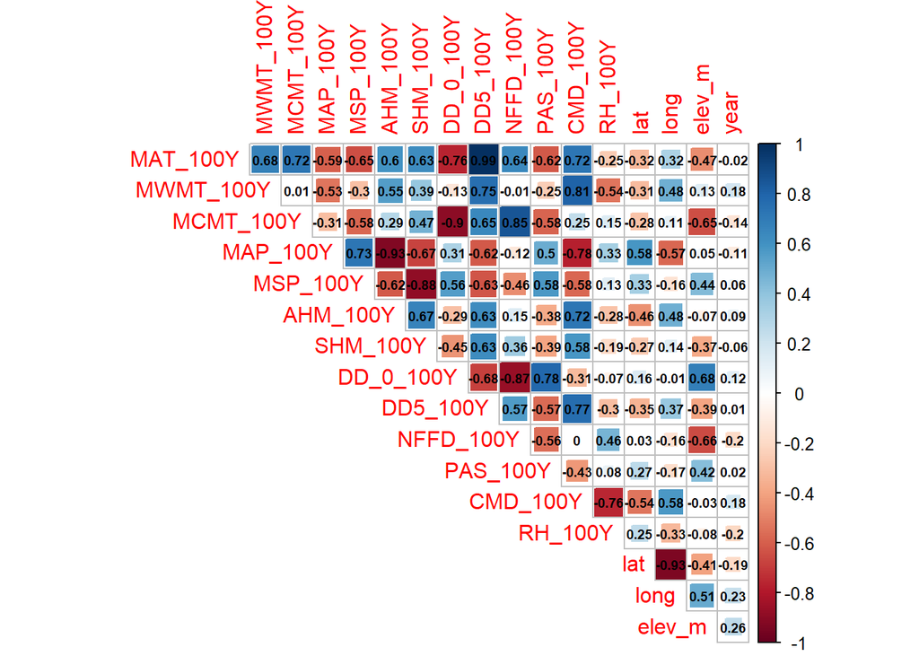

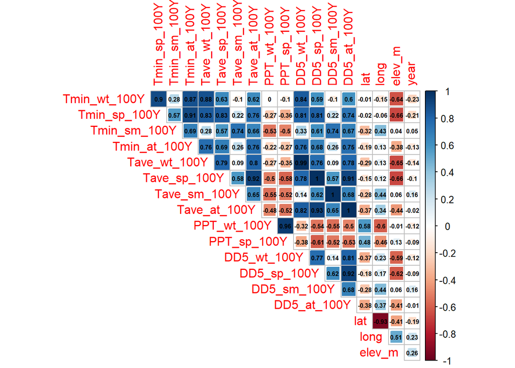

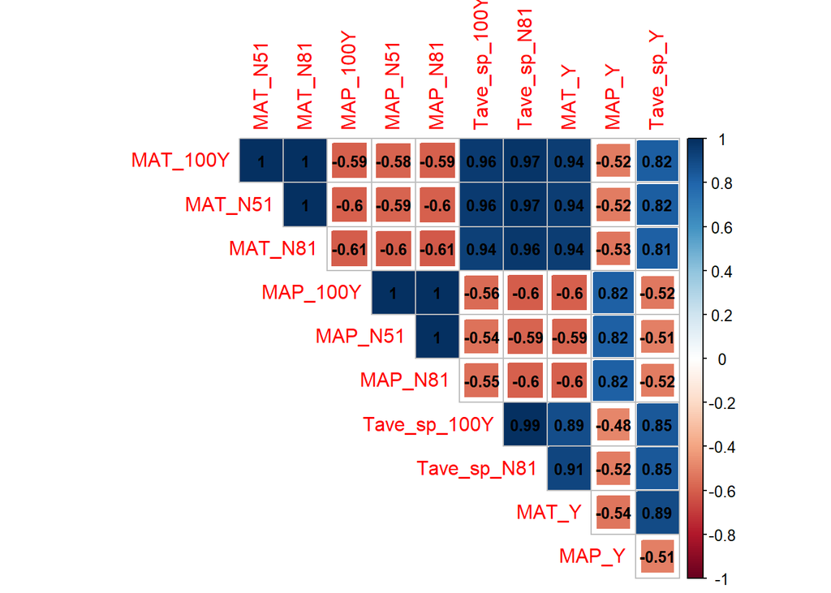

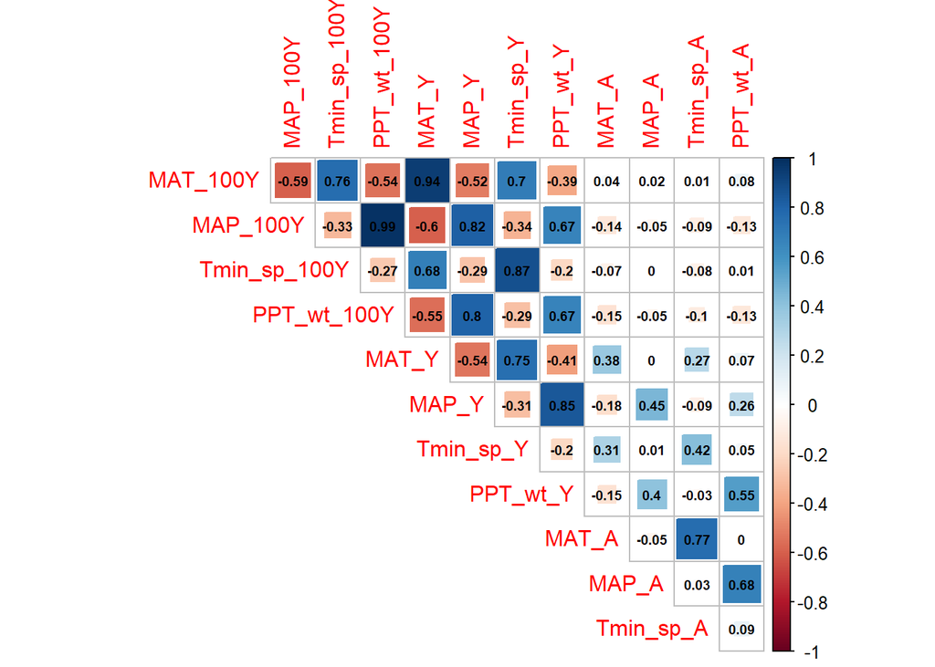

[Climatic]  
- *MAT* with MAP/MSP (.59), DD5 (~1), DD_0 (-.76), CMD:NFFD (.6-.7), PAS (.62)  
- *MAP* also with DD5 (.62), AHM (.9)  
- *Anomalies*: Some variables negatively correlated b/w _Y and _As

Year had no large correlations with any variables (all < .3). Normals strongly correlated from different periods - MAT x MAP correlations consistent.

## How have climate variables changed over time???

Objective:  
Describe trends and rates of change over time *across California* in the following types of variables in  
- YoC Climates  
- Climate Anomalies

Split by climate group and include as covariate? (As in Natalies *Streptanthus* analyses)

#### Annual Variables

Quantify rate of climate change in - Tmin wt and sp  
- PPT wt and sp  
- MAT  
_ MAP

Note: Though analyses of DOY ~ Climate may not include covariates (to focus on the effect of cliamte variables), geography (lat/long) and MAP are included here in addition to year to control for variation in climate over space. Also include PI when available.

**MAT**

```
##
## Call:
## lm(formula = MAT_Y ~ year + MAP_Y + elev_m + long + MAP_Y * elev_m *
##     long, data = nemo_df2)
##
## Residuals:
##     Min      1Q  Median      3Q     Max
## -5.6710 -0.6169  0.0324  0.6499  3.2395
##
## Coefficients:
##                     Estimate Std. Error t value Pr(>|t|)
## (Intercept)       -8.840e+00  2.573e+01  -0.344   0.7312
## year               1.180e-02  8.041e-04  14.680  < 2e-16 ***
## MAP_Y              1.604e+01  4.020e+00   3.989 6.93e-05 ***
## elev_m             1.139e-02  3.236e-02   0.352   0.7250
## long              -1.402e-02  2.130e-01  -0.066   0.9475
## MAP_Y:elev_m      -1.243e-02  4.853e-03  -2.560   0.0105 *
## MAP_Y:long         1.328e-01  3.334e-02   3.982 7.12e-05 ***
## elev_m:long        7.323e-05  2.718e-04   0.269   0.7876
## MAP_Y:elev_m:long -9.701e-05  4.065e-05  -2.386   0.0171 *
## ---
## Signif. codes:  0 '***' 0.001 '**' 0.01 '*' 0.05 '.' 0.1 ' ' 1
##
## Residual standard error: 1.027 on 1668 degrees of freedom
## Multiple R-squared:  0.7174, Adjusted R-squared:  0.7161
## F-statistic: 529.4 on 8 and 1668 DF,  p-value: < 2.2e-16
```

```
## Conditions used in construction of plot
## MAP_Y: 6.278521
## elev_m: 572.44
## long: -118.5411
```

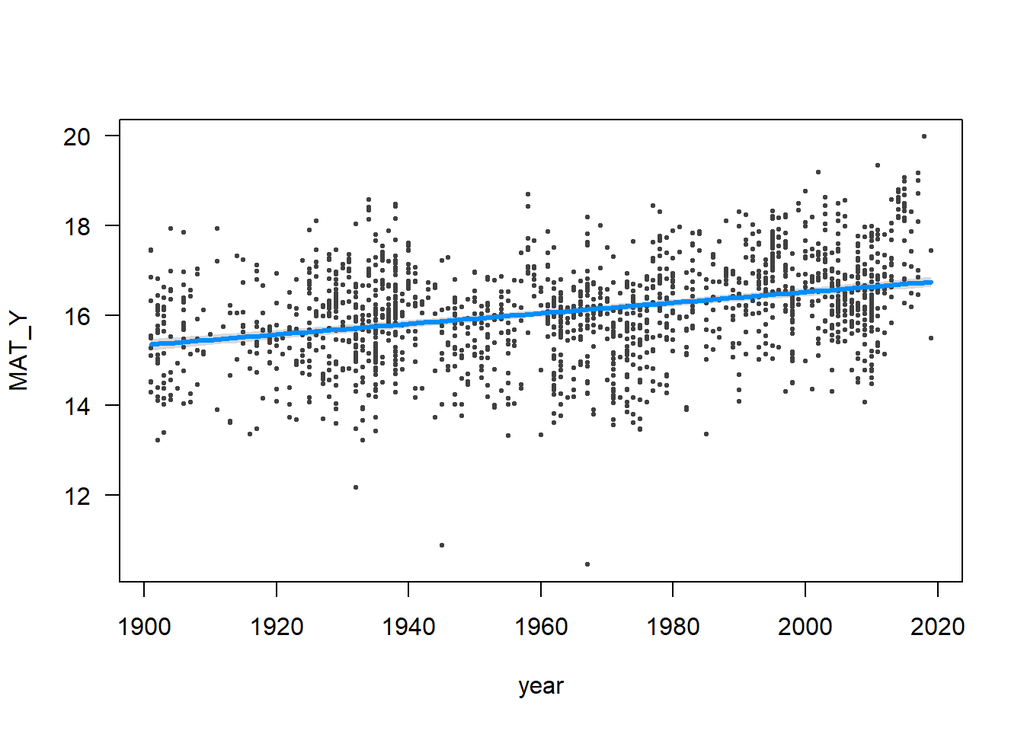

```
## JOHNSON-NEYMAN INTERVAL
##
## When long is OUTSIDE the interval [-122.40, -119.31], the slope of MAP_Y is
## p < .05.
##
## Note: The range of observed values of long is [-124.21, -115.51]
```

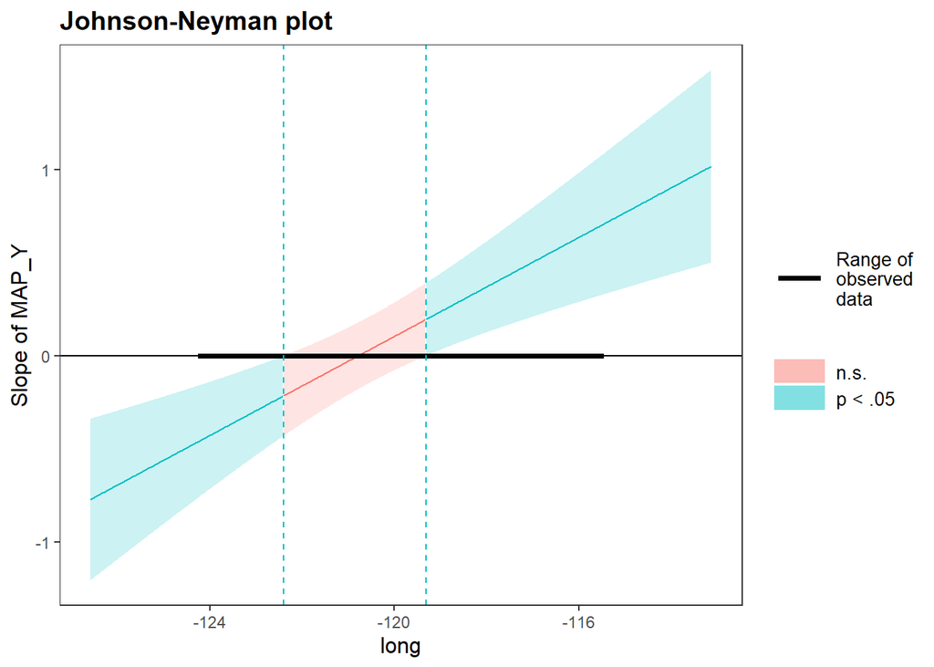

```
## JOHNSON-NEYMAN INTERVAL
##
## When long is INSIDE the interval [-122.73, -113.99], the slope of elev_m is
## p < .05.
##
## Note: The range of observed values of long is [-124.21, -115.51]
```

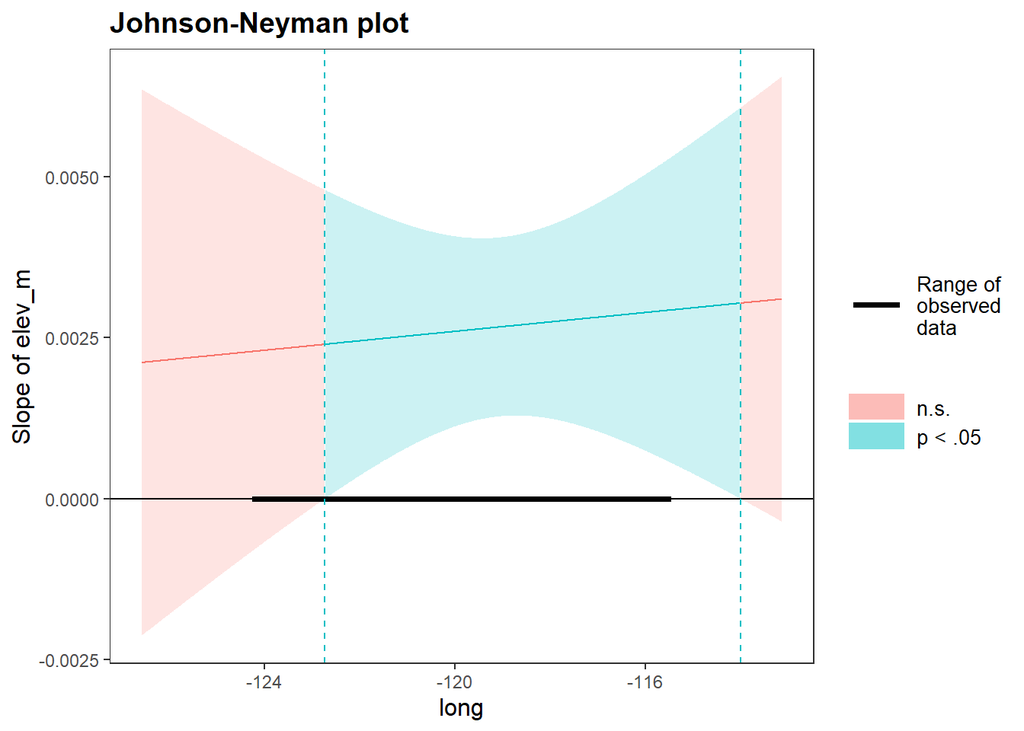

```
## JOHNSON-NEYMAN INTERVAL
##
## When elev_m is OUTSIDE the interval [880.16, 3472.93], the slope of MAP_Y
## is p < .05.
##
## Note: The range of observed values of elev_m is [-2.12, 2056.62]
```

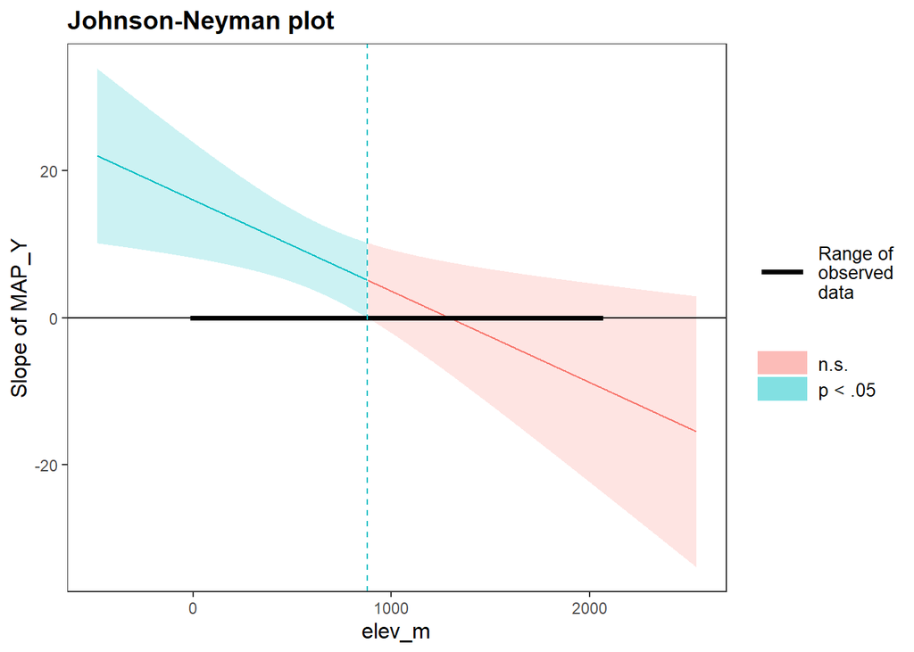

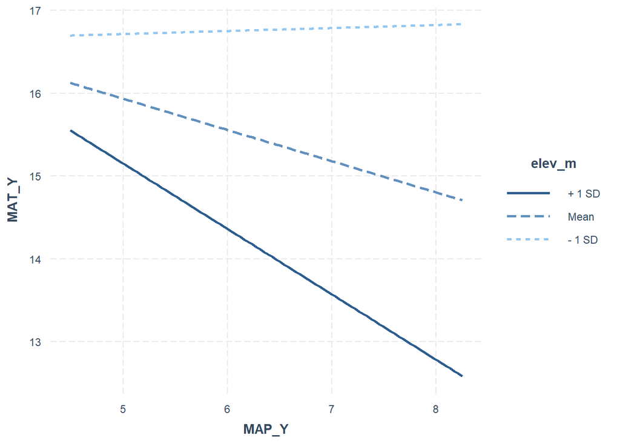

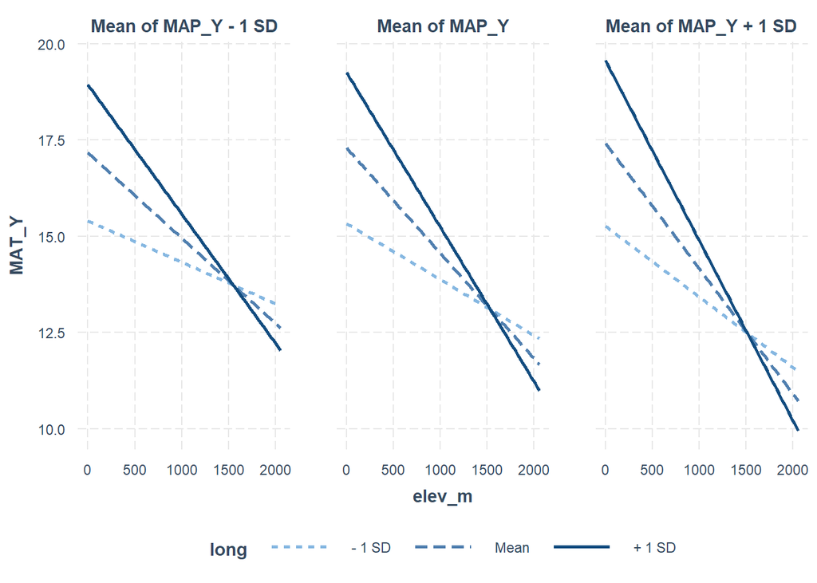

```
## [1] "MAT_Y warming (°C) over 120 years"
```

```
## [1] 1.416
```

**MAP**

```
##
## Call:
## lm(formula = MAP_Y ~ year + elev_m + long + MAT_Y, data = nemo_df2)
##
## Residuals:
##      Min       1Q   Median       3Q      Max
## -1.57053 -0.30414  0.02082  0.32706  1.32426
##
## Coefficients:
##               Estimate Std. Error t value Pr(>|t|)
## (Intercept) -5.311e+00  1.227e+00  -4.329 1.59e-05 ***
## year        -3.095e-04  3.899e-04  -0.794    0.427
## elev_m       2.011e-04  4.282e-05   4.697 2.85e-06 ***
## long        -1.137e-01  8.180e-03 -13.899  < 2e-16 ***
## MAT_Y       -9.835e-02  9.923e-03  -9.912  < 2e-16 ***
## ---
## Signif. codes:  0 '***' 0.001 '**' 0.01 '*' 0.05 '.' 0.1 ' ' 1
##
## Residual standard error: 0.4756 on 1672 degrees of freedom
## Multiple R-squared:  0.3915, Adjusted R-squared:  0.3901
## F-statistic: 268.9 on 4 and 1672 DF,  p-value: < 2.2e-16
```

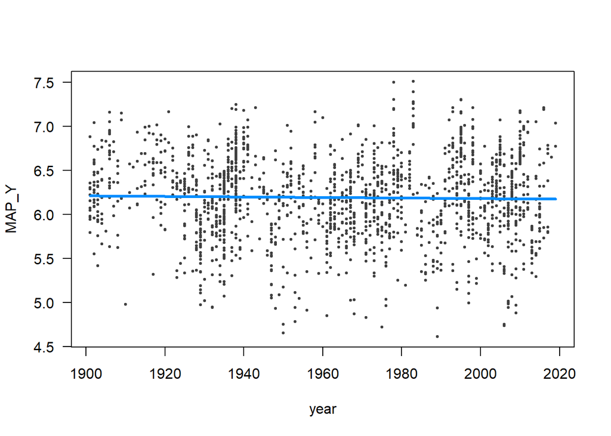

No significant change in average MAP over years of collection

**Frost Free Days**

```r
ffd_t1 <- lm(NFFD_Y ~ year + elev_m + long + MAP_Y, data = nemo_df2)
summary(ffd_t1)
```

```
##
## Call:
## lm(formula = NFFD_Y ~ year + elev_m + long + MAP_Y, data = nemo_df2)
##
## Residuals:
##      Min       1Q   Median       3Q      Max
## -174.280  -11.914    1.378   13.302   63.569
##
## Coefficients:
##               Estimate Std. Error t value Pr(>|t|)
## (Intercept) 506.586001  50.235630  10.084  < 2e-16 ***
## year          0.169317   0.016970   9.977  < 2e-16 ***
## elev_m       -0.046239   0.001412 -32.739  < 2e-16 ***
## long          4.360263   0.322200  13.533  < 2e-16 ***
## MAP_Y         5.816401   1.090253   5.335 1.09e-07 ***
## ---
## Signif. codes:  0 '***' 0.001 '**' 0.01 '*' 0.05 '.' 0.1 ' ' 1
##
## Residual standard error: 21.82 on 1672 degrees of freedom
## Multiple R-squared:  0.4146, Adjusted R-squared:  0.4132
## F-statistic:   296 on 4 and 1672 DF,  p-value: < 2.2e-16
```

```r
ffd_t1.1 <- lm(bFFP_Y ~ year + elev_m + long + MAP_Y, data = nemo_df2)
summary(ffd_t1.1)
```

```
##
## Call:
## lm(formula = bFFP_Y ~ year + elev_m + long + MAP_Y, data = nemo_df2)
##
## Residuals:
##     Min      1Q  Median      3Q     Max
## -82.716 -17.129   0.777  18.834  94.306
##
## Coefficients:
##               Estimate Std. Error t value Pr(>|t|)
## (Intercept) -3.247e+02  6.170e+01  -5.262 1.61e-07 ***
## year        -1.397e-01  2.084e-02  -6.700 2.83e-11 ***
## elev_m       5.690e-02  1.735e-03  32.803  < 2e-16 ***
## long        -5.542e+00  3.957e-01 -14.005  < 2e-16 ***
## MAP_Y       -5.000e+00  1.339e+00  -3.734 0.000195 ***
## ---
## Signif. codes:  0 '***' 0.001 '**' 0.01 '*' 0.05 '.' 0.1 ' ' 1
##
## Residual standard error: 26.79 on 1672 degrees of freedom
## Multiple R-squared:  0.4162, Adjusted R-squared:  0.4148
## F-statistic: 297.9 on 4 and 1672 DF,  p-value: < 2.2e-16
```

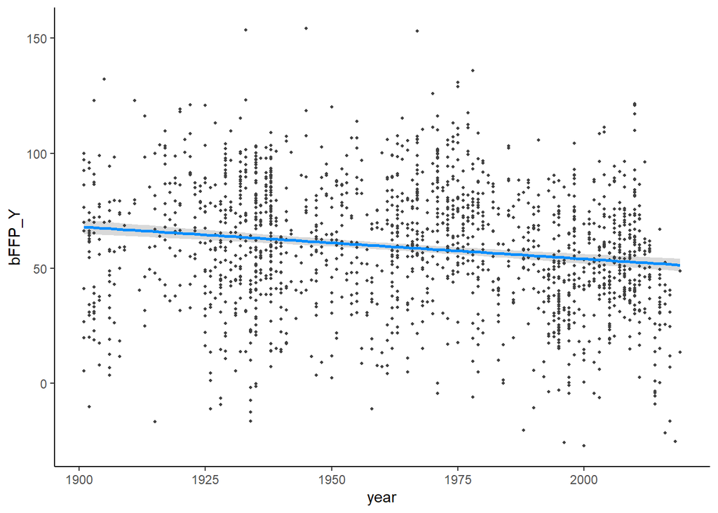

```r
visreg(ffd_t1.1, xvar = "year", points = list(col = "#404040"), gg = TRUE) +
  theme_classic()
```

#### Seasonal Variables

Note: See Climate_1.Rmd for selection of variables and seasons

#### Monthly (& custom windows)

Consider differences across geographic climate regions?

### Change in Anomalies over time

**MAT**

```
##
## Call:
## lm(formula = MAT_A ~ year + elev_m * long * MAT_Y, data = nemo_df2)
##
## Residuals:
##      Min       1Q   Median       3Q      Max
## -2.07983 -0.28579 -0.01249  0.27982  1.77174
##
## Coefficients:
##                     Estimate Std. Error t value Pr(>|t|)
## (Intercept)       -1.173e+02  8.204e+00 -14.299  < 2e-16 ***
## year               7.839e-03  3.802e-04  20.621  < 2e-16 ***
## elev_m             4.915e-02  9.234e-03   5.322 1.16e-07 ***
## long              -8.094e-01  6.829e-02 -11.851  < 2e-16 ***
## MAT_Y              5.021e+00  5.233e-01   9.595  < 2e-16 ***
## elev_m:long        3.948e-04  7.758e-05   5.089 4.00e-07 ***
## elev_m:MAT_Y      -1.752e-03  6.767e-04  -2.589  0.00972 **
## long:MAT_Y         3.937e-02  4.337e-03   9.079  < 2e-16 ***
## elev_m:long:MAT_Y -1.392e-05  5.707e-06  -2.440  0.01481 *
## ---
## Signif. codes:  0 '***' 0.001 '**' 0.01 '*' 0.05 '.' 0.1 ' ' 1
##
## Residual standard error: 0.4526 on 1668 degrees of freedom
## Multiple R-squared:  0.5188, Adjusted R-squared:  0.5165
## F-statistic: 224.8 on 8 and 1668 DF,  p-value: < 2.2e-16
```

```
## Conditions used in construction of plot
## elev_m: 572.44
## long: -118.5411
## MAT_Y: 15.1
```

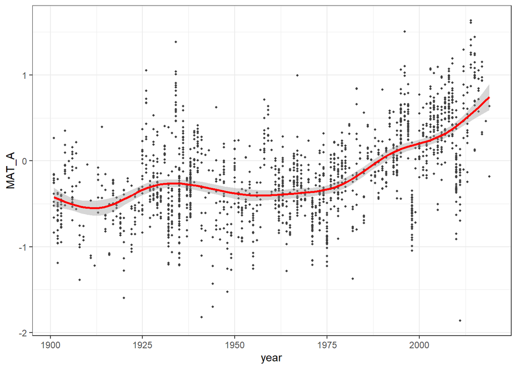

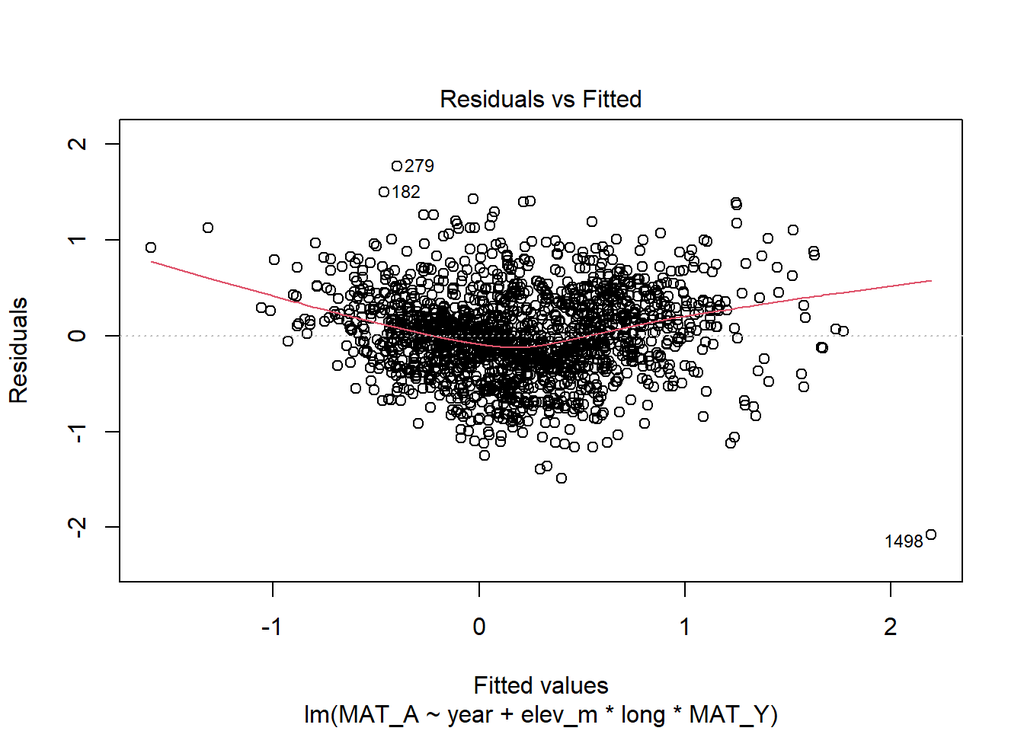

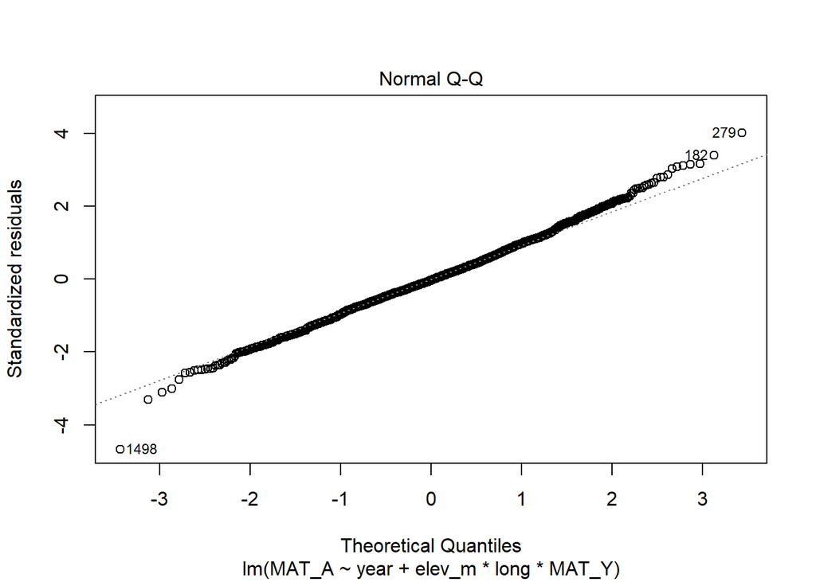

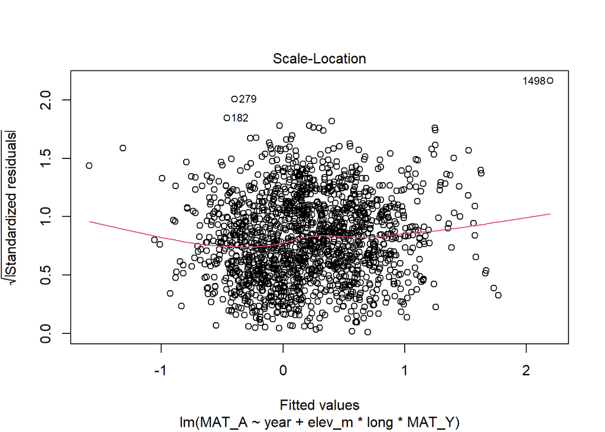

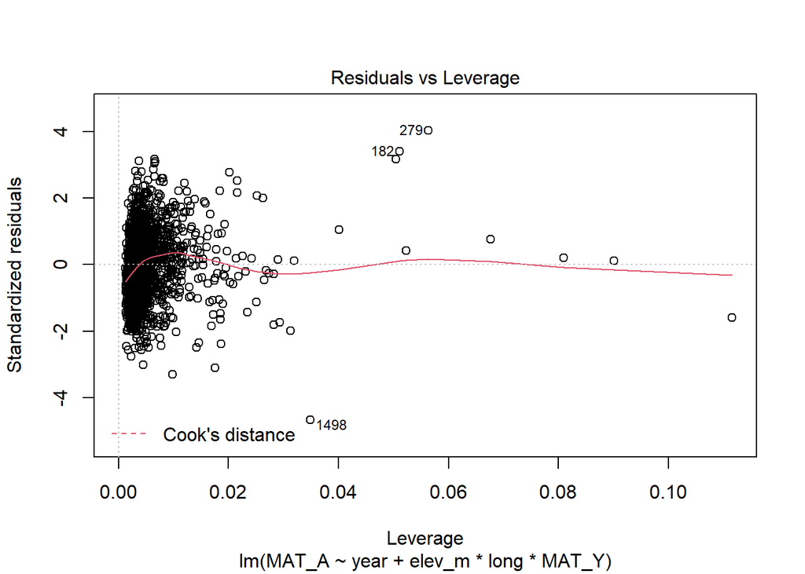

```
##  lag Autocorrelation D-W Statistic p-value
##    1       0.2169781      1.565992       0
##  Alternative hypothesis: rho != 0
```

```
## [1] "MAT anomalies (°C) increase over 120 years"
```

```
## [1] 0.84
```

Similar interactions explain variation in MAT_A…

**MAP**

```
##
## Call:
## lm(formula = MAP_A ~ year + elev_m + long + MAP_Y + MAT_Y, data = nemo_df2)
##
## Residuals:
##      Min       1Q   Median       3Q      Max
## -1515.78  -105.79    -1.71   117.91  1164.38
##
## Coefficients:
##               Estimate Std. Error t value Pr(>|t|)
## (Intercept) 3101.53148  492.42643   6.298 3.83e-10 ***
## year          -0.21546    0.15562  -1.385    0.166
## elev_m        -0.08822    0.01720  -5.129 3.26e-07 ***
## long          40.66925    3.44803  11.795  < 2e-16 ***
## MAP_Y        296.31325    9.76058  30.358  < 2e-16 ***
## MAT_Y         24.09437    4.07502   5.913 4.07e-09 ***
## ---
## Signif. codes:  0 '***' 0.001 '**' 0.01 '*' 0.05 '.' 0.1 ' ' 1
##
## Residual standard error: 189.8 on 1671 degrees of freedom
## Multiple R-squared:  0.3581, Adjusted R-squared:  0.3562
## F-statistic: 186.5 on 5 and 1671 DF,  p-value: < 2.2e-16
```

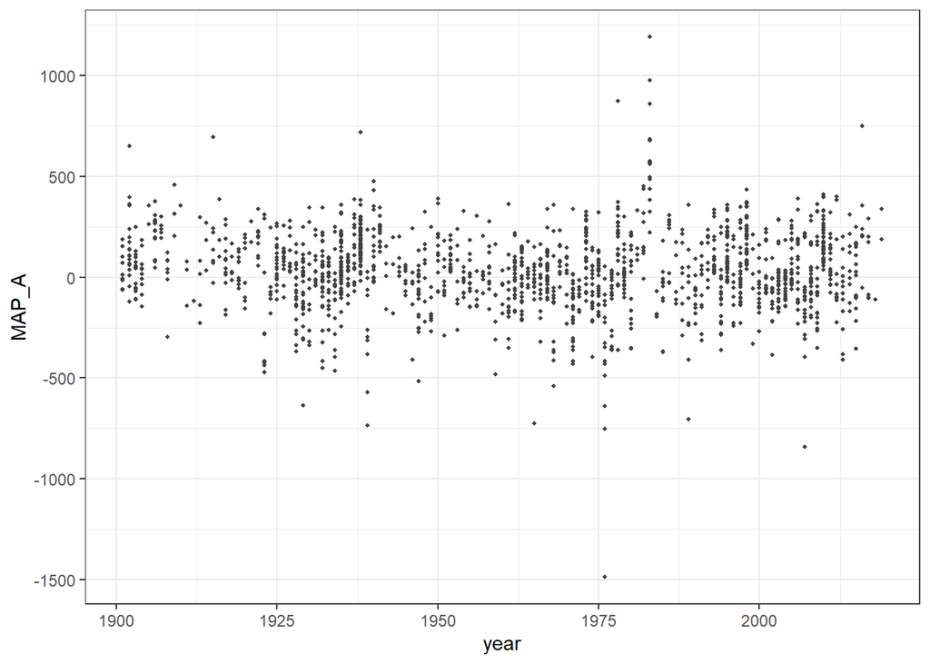

Slightly significant effect of year becomes ns when controlling for YoC MAP/MAT

## Effect of Error Distance on DOY ~ Climate models

The following analyses aim to measure the effect of different error distance on model outputs, specifically,

- $R^2$ values
- Parameter estimates and
- significance of climate variables in their effect on DOY

For 100 year averages for MAT, MAP, Tmin_sp, Tave_sp, PPT_sp, PPT_wt

Including error distance (or error bin) as a covariate shows no model improvement. Though the smallest bin, 0-2 km error, has a significant effect in the model, none of the parameter estimates of the bins are significantly different from one another.

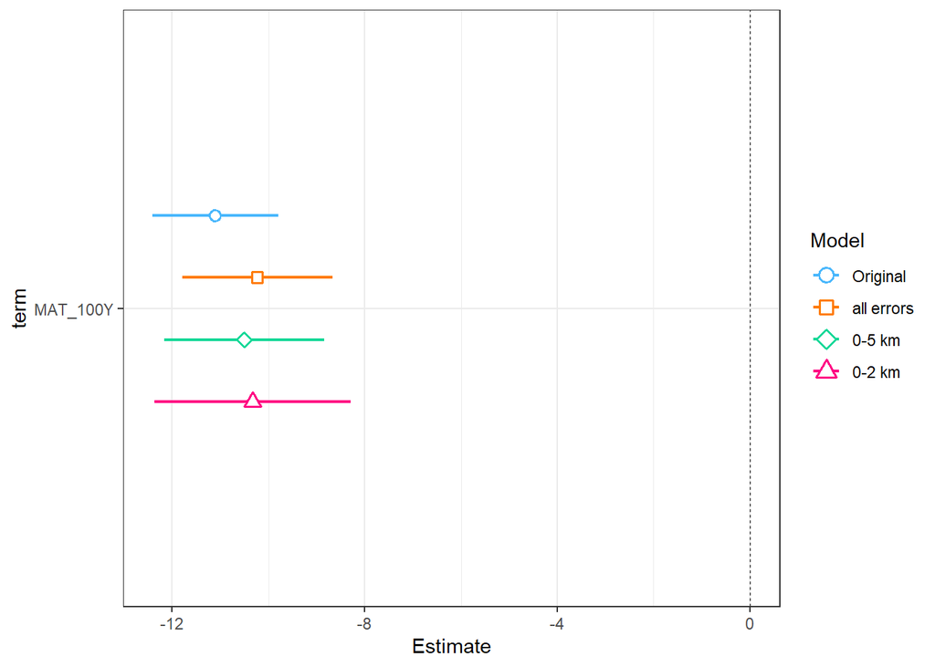

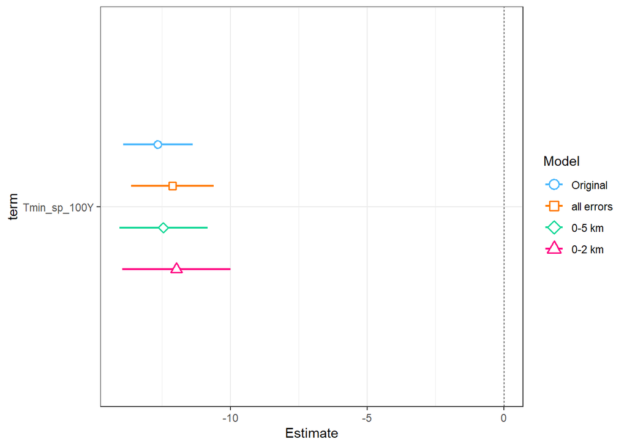

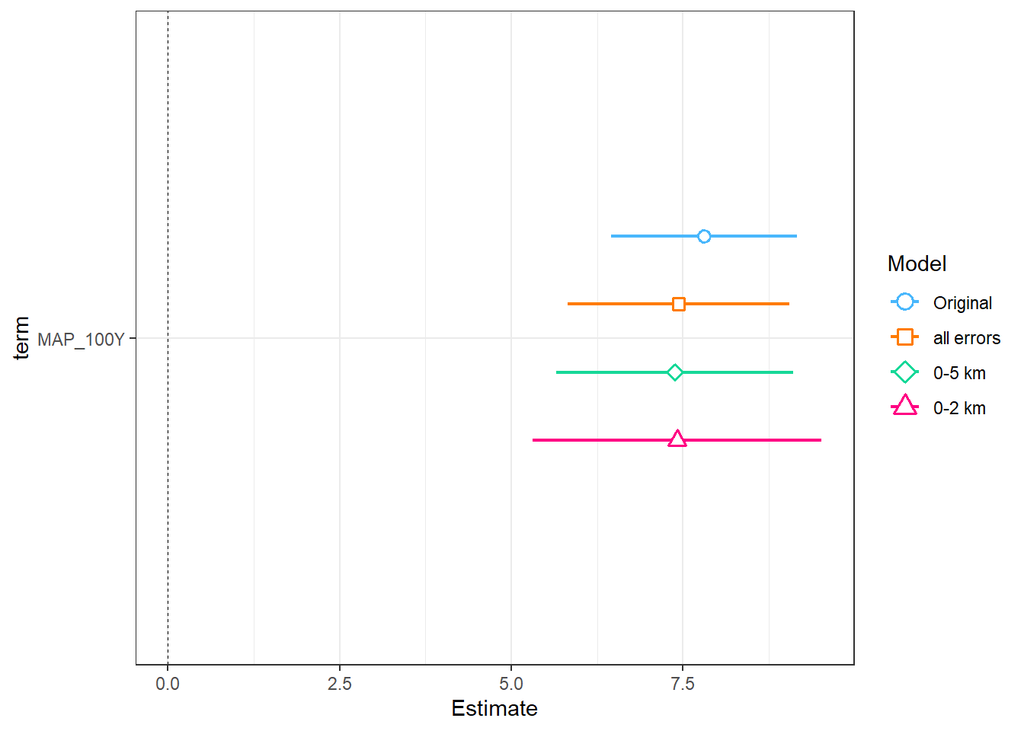

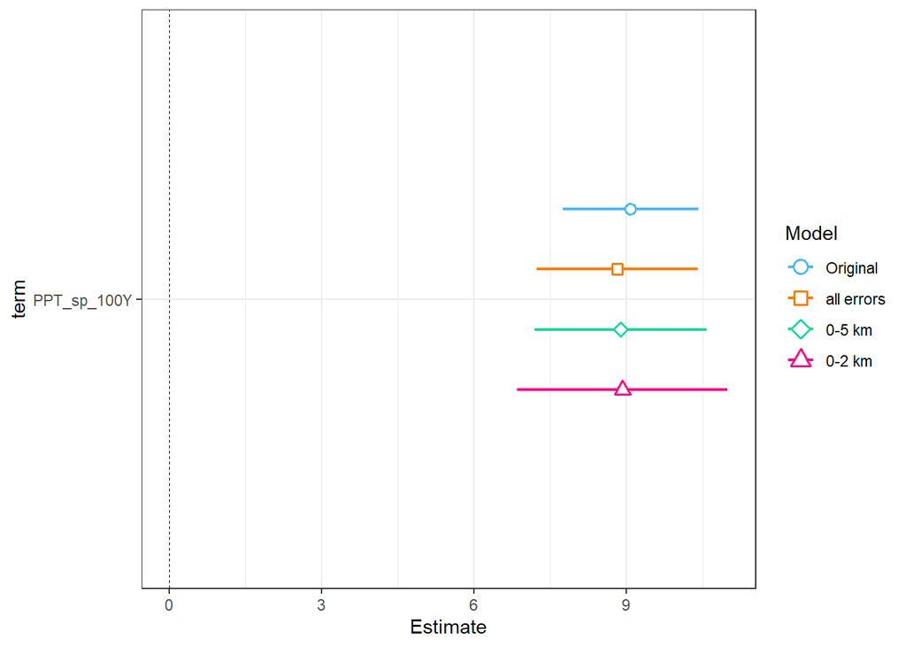

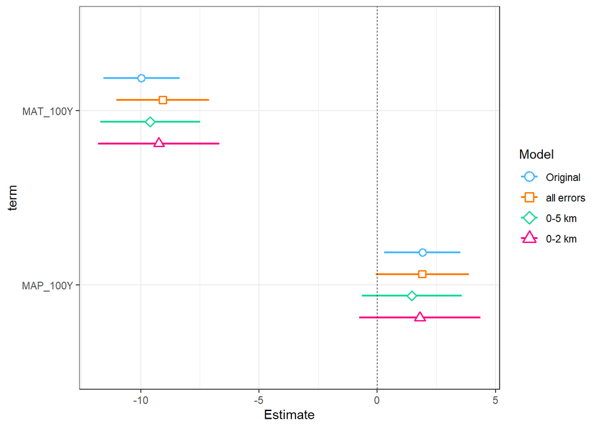

```
##
## Call:
## lm(formula = DOY ~ MAT_100Y + MAP_100Y, data = nemo_df2)
##
## Residuals:
##     Min      1Q  Median      3Q     Max
## -92.411 -17.273  -1.012  16.576 118.874
##
## Coefficients:
##             Estimate Std. Error t value Pr(>|t|)
## (Intercept) 163.2975    15.2966  10.675   <2e-16 ***
## MAT_100Y     -5.5855     0.4598 -12.148   <2e-16 ***
## MAP_100Y      3.7348     1.6079   2.323   0.0203 *
## ---
## Signif. codes:  0 '***' 0.001 '**' 0.01 '*' 0.05 '.' 0.1 ' ' 1
##
## Residual standard error: 27.11 on 1674 degrees of freedom
## Multiple R-squared:  0.1461, Adjusted R-squared:  0.1451
## F-statistic: 143.2 on 2 and 1674 DF,  p-value: < 2.2e-16
```

```
## [1] 0.1271034
```

```
## [1] 0.1311241
```

```
## [1] 0.1204958
```

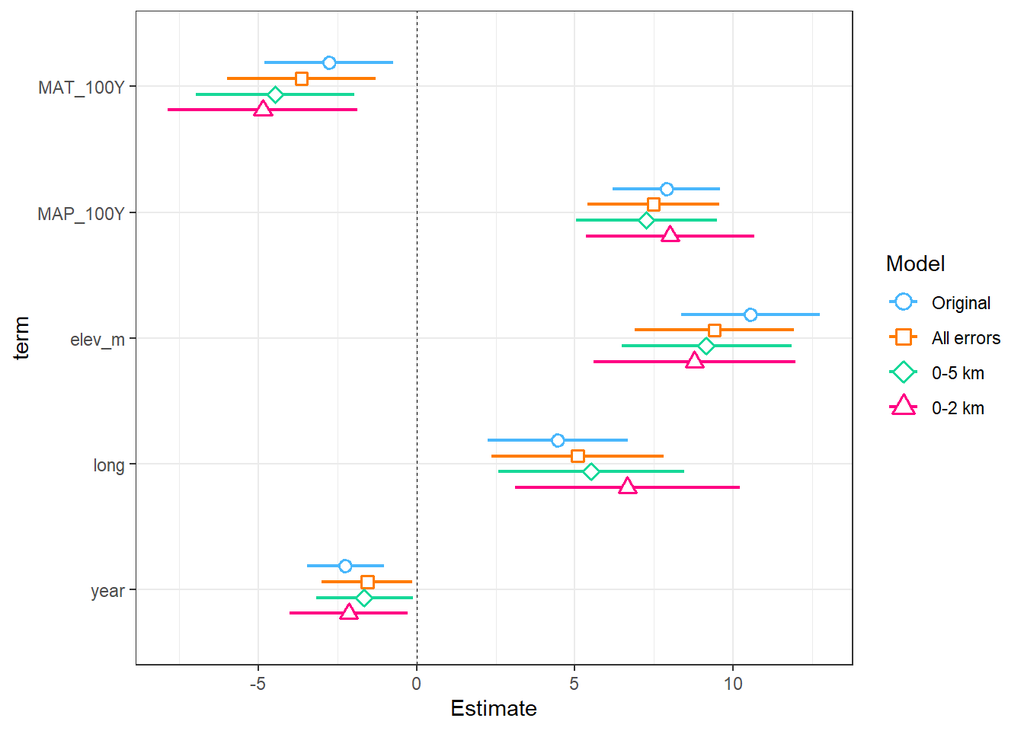

```
##
## Call:
## lm(formula = DOY ~ MAT_100Y + MAP_100Y + elev_m + long + year,
##     data = nemo_df2)
##
## Residuals:
##     Min      1Q  Median      3Q     Max
## -84.108 -14.867   0.053  14.836 147.637
##
## Coefficients:
##               Estimate Std. Error t value Pr(>|t|)
## (Intercept) 373.467511  71.233847   5.243 1.78e-07 ***
## MAT_100Y     -1.550047   0.582240  -2.662 0.007837 **
## MAP_100Y     15.450315   1.699227   9.093  < 2e-16 ***
## elev_m        0.021879   0.002319   9.434  < 2e-16 ***
## long          1.874374   0.471910   3.972 7.43e-05 ***
## year         -0.069089   0.019036  -3.629 0.000293 ***
## ---
## Signif. codes:  0 '***' 0.001 '**' 0.01 '*' 0.05 '.' 0.1 ' ' 1
##
## Residual standard error: 24.55 on 1671 degrees of freedom
## Multiple R-squared:  0.301,  Adjusted R-squared:  0.2989
## F-statistic: 143.9 on 5 and 1671 DF,  p-value: < 2.2e-16
```

```
## [1] 0.2926793
```

```
## [1] 0.3007084
```

```
## [1] 0.2976811
```

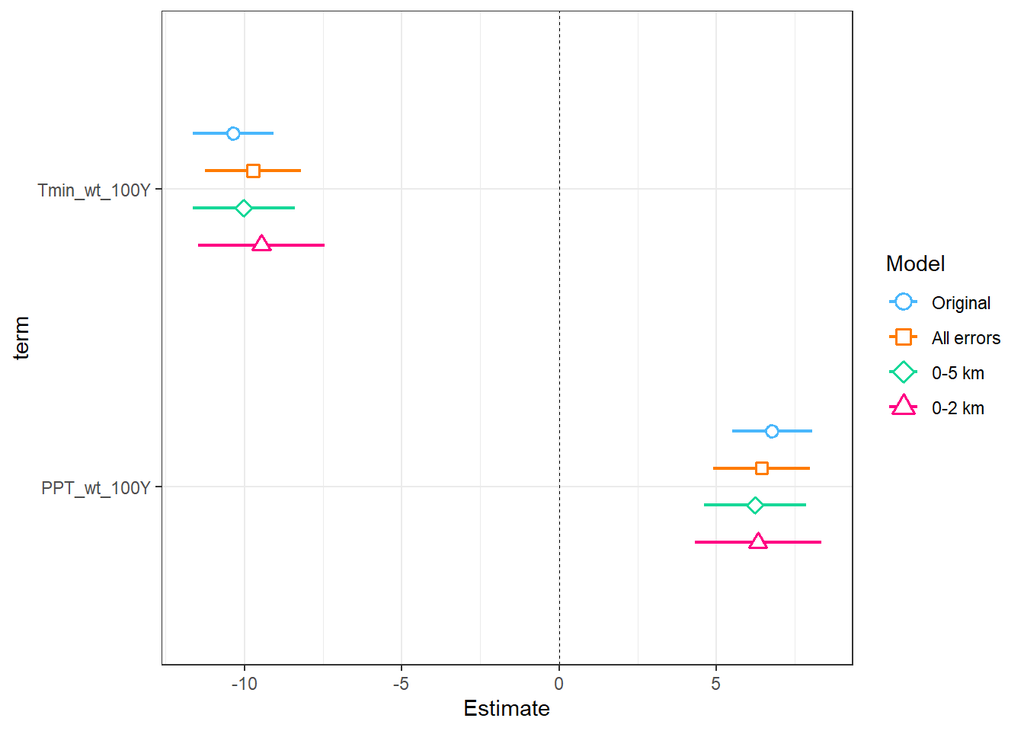

```
##
## Call:
## lm(formula = DOY ~ Tmin_wt_100Y + PPT_wt_100Y, data = nemo_df2)
##
## Residuals:
##     Min      1Q  Median      3Q     Max
## -83.497 -17.592  -1.428  17.248 137.692
##
## Coefficients:
##              Estimate Std. Error t value Pr(>|t|)
## (Intercept)   42.6650     7.1866   5.937 3.53e-09 ***
## Tmin_wt_100Y  -4.6510     0.2919 -15.934  < 2e-16 ***
## PPT_wt_100Y   12.9039     1.2386  10.418  < 2e-16 ***
## ---
## Signif. codes:  0 '***' 0.001 '**' 0.01 '*' 0.05 '.' 0.1 ' ' 1
##
## Residual standard error: 26.61 on 1674 degrees of freedom
## Multiple R-squared:  0.1773, Adjusted R-squared:  0.1763
## F-statistic: 180.4 on 2 and 1674 DF,  p-value: < 2.2e-16
```

```
## [1] 0.1618785
```

```
## [1] 0.1651836
```

```
## [1] 0.1448439
```

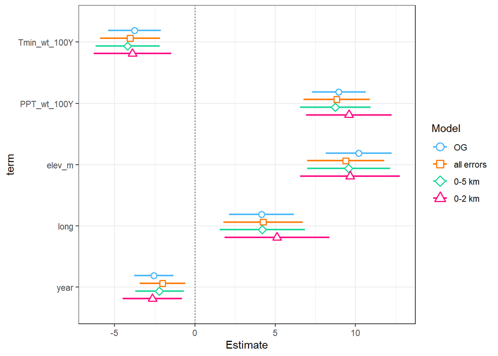

```
##
## Call:
## lm(formula = DOY ~ Tmin_wt_100Y + PPT_wt_100Y + elev_m + long +
##     year, data = nemo_df2)
##
## Residuals:
##     Min      1Q  Median      3Q     Max
## -83.006 -14.892  -0.621  14.906 153.197
##
## Coefficients:
##                Estimate Std. Error t value Pr(>|t|)
## (Intercept)  359.097898  62.937628   5.706 1.37e-08 ***
## Tmin_wt_100Y  -1.689955   0.374198  -4.516 6.74e-06 ***
## PPT_wt_100Y   17.089181   1.622966  10.530  < 2e-16 ***
## elev_m         0.021161   0.002175   9.729  < 2e-16 ***
## long           1.743720   0.432253   4.034 5.73e-05 ***
## year          -0.078835   0.019091  -4.129 3.82e-05 ***
## ---
## Signif. codes:  0 '***' 0.001 '**' 0.01 '*' 0.05 '.' 0.1 ' ' 1
##
## Residual standard error: 24.53 on 1671 degrees of freedom
## Multiple R-squared:  0.3019, Adjusted R-squared:  0.2998
## F-statistic: 144.5 on 5 and 1671 DF,  p-value: < 2.2e-16
```

```
## [1] 0.2928858
```

```
## [1] 0.2987398
```

```
## [1] 0.2928041
```

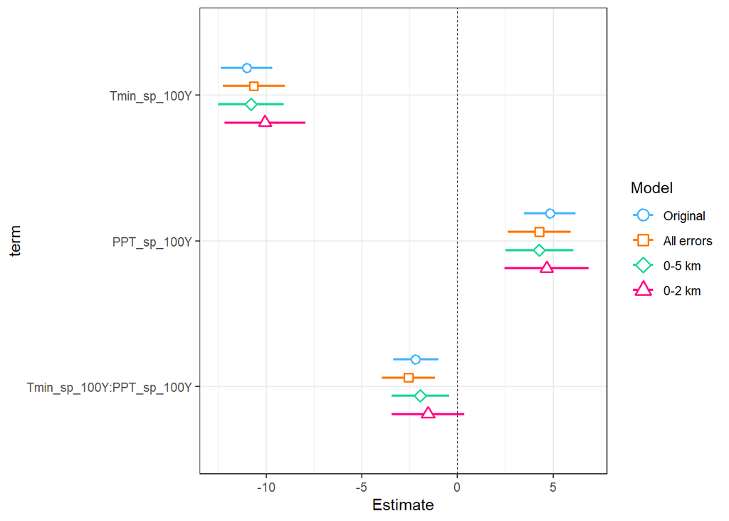

```
##
## Call:
## lm(formula = DOY ~ Tmin_sp_100Y + PPT_sp_100Y + Tmin_sp_100Y *
##     PPT_sp_100Y, data = nemo_df2)
##
## Residuals:
##    Min     1Q Median     3Q    Max
## -92.77 -16.07  -1.02  16.07 137.35
##
## Coefficients:
##                          Estimate Std. Error t value Pr(>|t|)
## (Intercept)               20.2243    18.8865   1.071 0.284399
## Tmin_sp_100Y               5.6785     3.0630   1.854 0.063927 .
## PPT_sp_100Y               23.0590     3.6850   6.258 4.96e-10 ***
## Tmin_sp_100Y:PPT_sp_100Y  -2.2324     0.6135  -3.639 0.000282 ***
## ---
## Signif. codes:  0 '***' 0.001 '**' 0.01 '*' 0.05 '.' 0.1 ' ' 1
##
## Residual standard error: 25.92 on 1673 degrees of freedom
## Multiple R-squared:  0.2199, Adjusted R-squared:  0.2185
## F-statistic: 157.2 on 3 and 1673 DF,  p-value: < 2.2e-16
```

```
## [1] 0.2086506
```

```
## [1] 0.2100489
```

```
## [1] 0.1861911
```

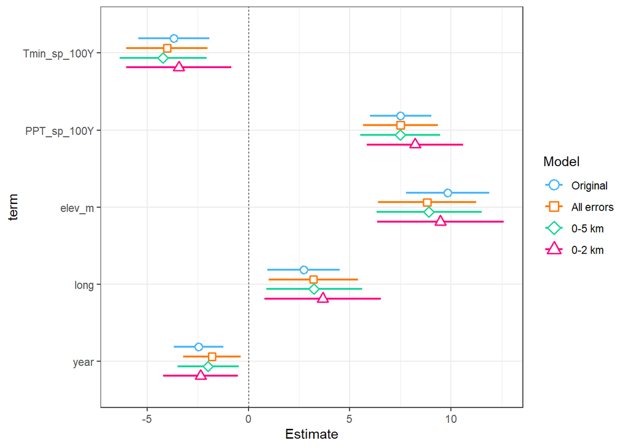

```
##
## Call:
## lm(formula = DOY ~ Tmin_sp_100Y + PPT_sp_100Y + elev_m + long +
##     year, data = nemo_df2)
##
## Residuals:
##     Min      1Q  Median      3Q     Max
## -82.539 -14.937  -0.524  15.097 150.818
##
## Coefficients:
##                Estimate Std. Error t value Pr(>|t|)
## (Intercept)  308.901885  60.762604   5.084 4.12e-07 ***
## Tmin_sp_100Y  -1.842038   0.446211  -4.128 3.84e-05 ***
## PPT_sp_100Y   15.322104   1.569475   9.763  < 2e-16 ***
## elev_m         0.020415   0.002172   9.401  < 2e-16 ***
## long           1.142965   0.382048   2.992  0.00282 **
## year          -0.075461   0.019047  -3.962 7.75e-05 ***
## ---
## Signif. codes:  0 '***' 0.001 '**' 0.01 '*' 0.05 '.' 0.1 ' ' 1
##
## Residual standard error: 24.44 on 1671 degrees of freedom
## Multiple R-squared:  0.3075, Adjusted R-squared:  0.3054
## F-statistic: 148.4 on 5 and 1671 DF,  p-value: < 2.2e-16
```

```
## [1] 0.3001584
```

```
## [1] 0.3076307
```

```
## [1] 0.2994759
```